# From Data to Decisions: Supervised Machine Learning with R

Hasthika Rupasinghe and Lasanthi Watagoda

2025-11-11

# What is supervised learning?

**Supervised learning** and **unsupervised learning** are two major branches of machine learning that differ in how they use data.

In supervised learning, we work with data that includes both **predictors** (inputs) and a *known* **outcome** (target). The goal is to learn a relationship between them so we can **predict** the outcome for *new data*. For example, predicting house prices based on square footage, number of bedrooms, and location, or classifying emails as “spam” or “not spam.” The model is “supervised” because it learns from examples where the correct answers are already known.

In contrast, unsupervised learning deals with data that has **no** **predefined** **outcome.** The goal is to **uncover** **hidden** **patterns** or structures within the data. Examples include grouping customers into segments based on purchasing behavior (clustering) or reducing many correlated variables into fewer informative components (principal component analysis, or PCA).

In this workshop, we will focus only on supervised learning, specifically regression (predicting continuous outcomes), as these methods form the foundation for most modern predictive modeling tasks.

# **Dataset Description**

The dataset used in this workshop summarizes long-term **hydrologic, climatic, and environmental characteristics** of Arctic and sub-Arctic watersheds from **1984–2018**. Each record represents a stream or river reach with associated climate, permafrost, and landscape information.

The **primary variable of interest** is the **mean groundwater contribution fraction (`bfi_mean`)**, It measures **how much of the stream’s flow comes from groundwater** rather than rain or snowmelt running over the land surface (surface flow). **Higher values** mean the stream is fed mostly by groundwater, while **lower values** mean it’s mainly fed by surface flow.

A second response variable, **`bfi_perchangeperyr`**, quantifies the **annual trend in groundwater contribution** over the same period — showing whether baseflow is increasing or decreasing through time.

Predictor variables (31) include a diverse set of watershed attributes:

- **Climatic factors:** mean annual temperature, precipitation, vapor pressure deficit, and radiation (each with long-term trends).
- **Landscape and topography:** elevation, slope, stream order, reach length, and drainage area.
- **Permafrost and soil properties:** permafrost type, active layer thickness, soil permeability, clay and carbon content.
- **Geographic variables:** latitude, longitude, and aspect.

## **Road Map**

| Step | Purpose | Example |
| --- | --- | --- |
| 1. Define the question | What do we want to predict? | Groundwater contribution (`bfi_mean`) |
| 2. Prepare the data | Clean, transform, and split | Training vs. testing data |
| 3. Build models | Try different algorithms | Linear, LASSO, ENet, Trees |
| 4. Evaluate performance | Measure accuracy | RMSE, R² |
| 5. Interpret & apply | Understand key drivers | Which predictors matter? |

# Loading libraries

```r
library(glmnet)        # for LASSO / Elastic Net
library(rpart)         # for decision trees
library(rpart.plot)    # tree plotting
library(ipred)         # for bagging
library(randomForest)  # for random forest
library(xgboost)       # for boosting
library(caret)         # for data splitting & RMSE calculation
library(dplyr)         # for when using %>% operator
```

# Data Cleaning and Loading

Data cleaning is a **mandatory and often time-consuming** step in any data-driven analysis. It involves identifying and correcting errors, handling inconsistent formats, detecting and addressing outliers, and managing missing or implausible values through methods such as imputation or removal. A properly cleaned dataset ensures that models are built on reliable and interpretable information rather than noise.

For the purpose of this workshop, we will **skip the data cleaning stage** so that we can focus on modeling concepts and practical applications. You are provided with a **pre-cleaned dataset**, which has been prepared in advance to remove missing values, correct encoding issues, and standardize variable names. This allows us to devote our session entirely to exploring and comparing supervised learning methods in R.

There are many ways to bring data into R, depending on the file type and source. You can import spreadsheets from Excel, text files such as `.csv` or `.txt`, connect directly to databases, access APIs, or even pull data from online repositories.

In this workshop, we will keep things simple by **using a pre-cleaned `.rds` file** that you can download beforehand. The `.rds` format is an R-specific file type that preserves the full structure of your dataset — including variable types and labels — making it easy to load and use with a single command. This ensures everyone works with the **same, clean, and consistent dataset** without worrying about formatting or import issues.

## Loading a downloaded data set

```r
## ---- (1) Load cleaned dataset ----
# If you saved as .rds:
data <- readRDS("Evans_clean.rds")

# or, if you saved as .csv:
# data <- read.csv("Evans_clean.csv")
```

## Look at the structure of the data set

```r
str(data)              # check structure (types, dimensions)
```

```
## tibble [9,972 × 35] (S3: tbl_df/tbl/data.frame)
##  $ bfi_mean                       : num [1:9972] 0.485 0.535 0.286 0.49 0.491 0.451 0.408 0.27 0.473 0.438 ...
##  $ site_id                        : num [1:9972] 2.5e+07 2.5e+07 2.5e+07 2.5e+07 2.5e+07 ...
##  $ bfi_perchangeperyr             : num [1:9972] 1.064 0.282 0 0.816 -0.51 ...
##  $ bfi_pval                       : num [1:9972] 0.058 0.164 0.339 0.019 0.15 0.159 0.142 0.106 0.313 0.523 ...
##  $ mean_annual_precip_mm          : num [1:9972] 18.1 17.6 20.4 13.8 15.7 ...
##  $ precip_pct_change_annual       : num [1:9972] 0.78 0.64 0.35 0.64 0.76 0.63 0.93 0.78 1.26 0.89 ...
##  $ mean_annual_snow_cm            : num [1:9972] 347 1000 1000 1000 276 ...
##  $ snow_pct_change_annual         : num [1:9972] 0.01 0 0 0 0 0 0 0 0 0 ...
##  $ mean_annual_temp_deg_c         : num [1:9972] -8.86 -10.43 -7.7 -10.32 -8.15 ...
##  $ temp_pct_change_annual         : num [1:9972] -1.63 -1.32 -1.44 -1.43 -1.95 -1.31 -1.19 -1.32 -1.27 -1.41 ...
##  $ mean_annual_vpd_k_pa           : num [1:9972] 0.31 0.29 0.29 0.28 0.31 0.29 0.26 NA 0.27 0.28 ...
##  $ vpd_pct_change_annual          : num [1:9972] 0.73 0.75 0.6 0.76 0.76 0.65 0.7 NA 0.75 0.72 ...
##  $ mean_annual_r_net_w_m2         : num [1:9972] -0.38 -0.33 -0.12 -0.28 -0.32 0.25 -0.13 NA -0.32 -0.25 ...
##  $ r_net_pct_change_annual        : num [1:9972] -0.37 -0.36 -0.67 -0.38 -0.31 -0.04 -0.91 NA -0.47 -0.57 ...
```

[output cut: 21 more lines]

## One way to handdle missing values

```r
## ---- (2) Define response and predictors ----
# We'll predict mean groundwater contribution (BFI_mean)
# Remove ID or non-predictor columns if still present
# Remove bfi_perchangeperyr, the other response variable
# Remove aspect_degree as it was converted to degrees to sin/cos (N=0/360, E=90)
data <- subset(data, select = -c(bfi_perchangeperyr, aspect_degree, site_id, bfi_pval, centroid_lon))
# OR
#data <- data %>%
#  select(
#    -bfi_pval,
#    -centroid_lon,
#    -site_id
#  )

# Drop remaining rows with any missing predictor
data_clean <- na.omit(data)

str(data_clean)
```

```
## tibble [3,083 × 30] (S3: tbl_df/tbl/data.frame)
##  $ bfi_mean                       : num [1:3083] 0.687 0.624 0.614 0.689 0.291 0.707 0.695 0.592 0.579 0.615 ...
##  $ mean_annual_precip_mm          : num [1:3083] 28.4 21.8 25.6 25.1 20.3 ...
##  $ precip_pct_change_annual       : num [1:3083] 0.09 0.13 0.18 0.18 0.33 0.08 0.25 0.42 0.25 0.37 ...
##  $ mean_annual_snow_cm            : num [1:3083] 10.11 5.81 9.11 8.54 5.4 ...
##  $ snow_pct_change_annual         : num [1:3083] -1.73 -2.63 -1.77 -1.82 -2.7 -2.09 -1.96 -0.46 -0.66 0.54 ...
##  $ mean_annual_temp_deg_c         : num [1:3083] -0.13 0.07 -0.63 -0.52 -0.73 0.16 -0.92 -0.29 -0.41 0.36 ...
##  $ temp_pct_change_annual         : num [1:3083] -54.33 84.04 -10.25 -12.45 -7.63 ...
##  $ mean_annual_vpd_k_pa           : num [1:3083] 0.54 0.53 0.52 0.52 0.53 0.52 0.53 0.53 0.51 0.55 ...
##  $ vpd_pct_change_annual          : num [1:3083] 0.38 0.39 0.39 0.37 0.38 0.38 0.4 0.4 0.39 0.39 ...
##  $ mean_annual_r_net_w_m2         : num [1:3083] 0.53 0.44 0.55 0.51 0.53 0.54 0.53 0.54 0.59 0.62 ...
##  $ r_net_pct_change_annual        : num [1:3083] 0.42 0.45 0.34 0.42 0.45 0.28 0.54 0.67 0.57 0.5 ...
##  $ magt_deg_c                     : num [1:3083] 1.772 1.569 1.458 0.456 0.891 ...
##  $ mean_annual_lai                : num [1:3083] 2.61 2.99 1.46 2.68 2.33 ...
##  $ centroid_lat_dec_degree        : num [1:3083] 70.5 70.3 70.3 70.3 70.2 ...
```

[output cut: 18 more lines]

```r
#head(data_clean) # Shows the first 6 rows of the dataset
library(DT)
datatable(head(data_clean, 10),
          caption = "Preview of the Clean Dataset",
          options = list(pageLength = 5, scrollX = TRUE))
```

|  | bfi_mean | mean_annual_precip_mm | precip_pct_change_annual | mean_annual_snow_cm | snow_pct_change_annual | mean_annual_temp_deg_c | temp_pct_change_annual | mean_annual_vpd_k_pa | vpd_pct_change_annual | mean_annual_r_net_w_m2 | r_net_pct_change_annual | magt_deg_c | mean_annual_lai | centroid_lat_dec_degree | elev_m | reach_slope_m_m | upstrm_drainage_area_km2 | reach_length_km | stream_order | permafrost_type | glacier_presence | alt_mean_m | alt_pct_change_annual | permeability_log10m2 | bulk_density_cg_cm_3 | coarse_fragment_cm3_dm3 | clay_content_g_kg | soil_organic_carbon_100cm_kg_m2 | aspect_sin | … |
| --- | --- | --- | --- | --- | --- | --- | --- | --- | --- | --- | --- | --- | --- | --- | --- | --- | --- | --- | --- | --- | --- | --- | --- | --- | --- | --- | --- | --- | --- | --- |
| 1 | 0.687 | 28.43 | 0.09 | 10.11 | -1.73 | -0.13 | -54.33 | 0.54 | 0.38 | 0.53 | 0.42 | 1.772017121 | 2.612833261 | 70.489 | 56.29 | 0.0072 | 131.07 | 4.88 | 2 | isolated | no | 0.5745 | 3.481288077 | -12.5 | 96.1 | 225.13 | 108.93 | 31.5 | -0.9999994516886945 | … |
| 2 | 0.624 | 21.78 | 0.13 | 5.81 | -2.63 | 0.07 | 84.04 | 0.53 | 0.39 | 0.44 | 0.45 | 1.568644404 | 2.987306833 | 70.316 | 29.8 | 0.0024 | 889.47 | 6.37 | 2 | isolated | no | 0.565 | 3.539823009 | -11.8 | 104.28 | 169.9 | 133.98 | 7.2 | -0.7122711002594665 | … |
| 3 | 0.614 | 25.58 | 0.18 | 9.11 | -1.77 | -0.63 | -10.25 | 0.52 | 0.39 | 0.55 | 0.34 | 1.457619905 | 1.460639477 | 70.292 | 349.5 | 0.0066 | 509.05 | 6.86 | 2 | sporadic | no | 0.5515 | 3.108405647 | -15.2 | 110.43 | 233.7 | 153.9 | 14 | -0.6004202253258841 | … |
| 4 | 0.689 | 25.11 | 0.18 | 8.54 | -1.82 | -0.52 | -12.45 | 0.52 | 0.37 | 0.51 | 0.42 | 0.455924183 | 2.680799723 | 70.271 | 349.74 | 0.0031 | 91.16 | 7.38 | 2 | sporadic | no | 0.567 | 3.359368439 | -15.2 | 119.28 | 160.88 | 138.1 | 14 | -0.3931396627937339 | … |
| 5 | 0.291 | 20.3 | 0.33 | 5.4 | -2.7 | -0.73 | -7.63 | 0.53 | 0.38 | 0.53 | 0.45 | 0.890734375 | 2.325411081 | 70.154 | 183.1 | 0.0079 | 60.8 | 12.67 | 1 | sporadic | no | 0.581 | 3.360380297 | -15.2 | 116.2 | 220.43 | 80.68 | 4.6 | 0.9744093113100726 | … |
| 6 | 0.707 | 26.17 | 0.08 | 8.52 | -2.09 | 0.16 | 41.11 | 0.52 | 0.38 | 0.54 | 0.28 | 1.995195508 | 2.445753098 | 70.438 | 194.99 | 0.0377 | 27.06 | 2.33 | 1 | isolated | no | 0.551 | 3.111226342 | -15.2 | 112.4 | 190.1 | 121.6 | 14 | -0.7889768598239169 | … |
| 7 | 0.695 | 21.97 | 0.25 | 7.1 | -1.96 | -0.92 | -6.38 | 0.53 | 0.4 | 0.53 | 0.54 | 1.52774179 | 2.437240601 | 69.956 | 122.31 | 0.0011 | 10694.91 | 7.12 | 5 | isolated | no | 0.608 | 3.52443609 | -14.1 | 119.48 | 245.03 | 97.03 | 31.5 | -0.2650512819348 | … |
| 8 | 0.592 | 19.38 | 0.42 | 5.65 | -0.46 | -0.29 | -16.46 | 0.53 | 0.4 | 0.54 | 0.67 | 1.572085977 | 2.957378387 | 69.617 | 133.01 | 0.0005 | 371.44 | 5.62 | 2 | isolated | no | 0.573 | 2.991772625 | -14.1 | 122.98 | 210.08 | 93.73 | 31.5 | 0.6186826734810978 | … |
| 9 | 0.579 | 18.96 | 0.25 | 5.6 | -0.66 | -0.41 | -12.6 | 0.51 | 0.39 | 0.59 | 0.57 | 0.974824011 | 2.605119944 | 69.779 | 261.93 | 0.0026 | 359.95 | 5.2 | 2 | sporadic | no | 0.501 | 3.896967969 | -14.1 | 133.2 | 195.08 | 102.8 | 31.5 | 0.997119322550888 | … |
| 10 | 0.615 | 18.28 | 0.37 | 4.1 | 0.54 | 0.36 | 12.43 | 0.55 | 0.39 | 0.62 | 0.5 | 1.19268322 | 2.536436319 | 69.551 | 119.84 | 0.0036 | 35.39 | 6.68 | 1 | sporadic | no | 0.7685 | 0.867490783 | -14.1 | 131.38 | 154.53 | 86.83 | 31.5 | -0.08437350613868268 | … |

# EDA (not covered in this workshop)

It’s quite common (and good practice) to start with **exploratory data analysis (EDA)** — including scatterplots, histograms, and correlation matrices — *before* building models.

### **Why we explore the data first**

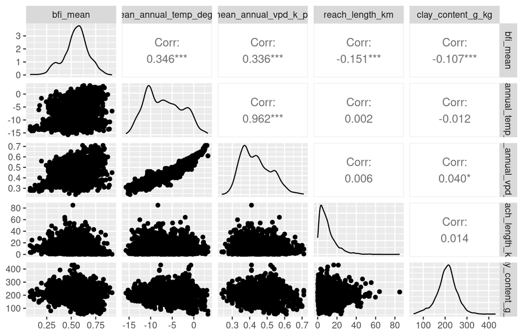

```r
# Quick look at pairwise relationships
library(GGally)

# Select a few key variables for clarity
subset_vars <- data_clean %>%
  select(bfi_mean, mean_annual_temp_deg_c, mean_annual_vpd_k_pa,
         reach_length_km, clay_content_g_kg)

ggpairs(subset_vars)
```

> “We can already see that `bfi_mean` tends to increase with temperature and decrease with clay content — patterns we’ll test more formally using our regression models.”

# Split data into training and test sets

When we build a predictive model, our goal is **not** just to explain the data we already have, but to make **accurate** **predictions** on **new**, **unseen** data. To evaluate how well a model generalizes, we divide the dataset into two parts: a *training* set and a *test* set.

The training set is used to fit the model—to learn patterns, relationships, or parameters. The test set, which the model has never seen during training, is then used to assess how well the model performs on new data. This separation helps us estimate the model’s true predictive ability.

Without this split, we risk **overfitting**, which happens when a model learns the training data too well—including its noise or random fluctuations—rather than the underlying structure. An overfitted model will show excellent performance on the training data but perform poorly on new data. Splitting data into training and test sets provides an honest assessment of a model’s generalization and helps us select models that are both accurate and robust.

```r
## ---- (3) Split into training and test sets (80/20) ----
set.seed(123)
train_idx <- createDataPartition(data_clean$bfi_mean, p = 0.8, list = FALSE)
train <- data_clean[train_idx, ]
test  <- data_clean[-train_idx, ]

nrow(train); nrow(test)
```

```
## [1] 2468
```

```
## [1] 615
```

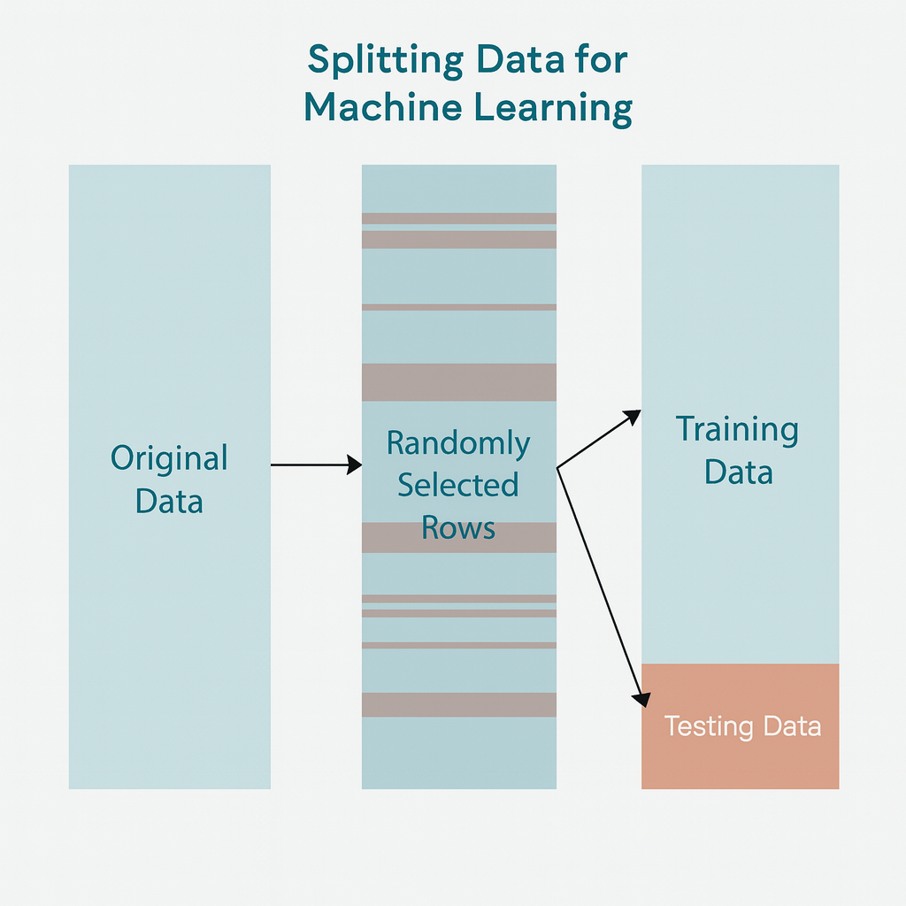

# Building models

In this section, we will build a series of regression models to predict the mean groundwater contribution fraction (`bfi_mean`) using several environmental and hydrologic predictors. Each model represents a different approach to learning the relationship between the predictors and the outcome. We begin with Linear Regression, a simple and interpretable model that assumes a straight-line relationship between the predictors and the response. Next, we extend this idea using LASSO type Regression models, which introduces regularization to automatically select the most important variables and prevent overfitting.

We then explore Decision Trees, which capture nonlinear patterns by splitting the data into smaller, more homogeneous groups based on predictor values. To improve upon a single tree’s instability, we introduce ensemble methods — specifically Bagging, Random Forest, and Boosting — that combine the results of many trees to produce more robust and accurate predictions.

By comparing these models, we will see how different techniques balance simplicity, flexibility, and predictive performance, helping us understand when each approach might be most effective in practical regression problems.

# Evaluating Predictive Models

When evaluating predictive models, there are many possible performance measures depending on the type of problem and the modeling goal. For regression models, some commonly used metrics include Mean Absolute Error (MAE), Mean Squared Error (MSE), Root Mean Squared Error (RMSE), and R-squared (R²). In classification problems, we often use measures such as accuracy, precision, recall, F1-score, and AUC (Area Under the Curve).

In this workshop, we will focus on two key metrics that are widely used for regression models — RMSE and R-squared (R²) — as they provide complementary perspectives on model quality.

The Root Mean Squared Error (RMSE) measures the average magnitude of prediction errors, showing how far the predicted values are from the observed values on average. It is calculated as the square root of the mean squared difference between actual and predicted values. A smaller RMSE indicates higher predictive accuracy.

The R-squared (R²) value represents the proportion of variability in the outcome variable that can be explained by the model. It ranges from 0 to 1, where values closer to 1 indicate a better fit.

In summary:

- RMSE quantifies prediction accuracy — lower values are better.
- R² quantifies explanatory power — higher values are better.

Together, these two measures give us a clear and interpretable summary of how well a model performs on unseen data.

## (1) LINEAR REGRESSION - Baseline model

### **Linear Regression**

Linear regression models the relationship between a response variable ( $y$ ) and one or more predictors ( $x_1, x_2, \dots, x_p$ ) by fitting a straight line (or hyperplane) that best describes the data.

$${y}_i = \beta_0 + \beta_1 x_{i1} +
\beta_2 x_{i2} + \cdots + \beta_p x_{ip}+\epsilon_i$$

where

- ${y}_i$ = the response for observation ( $i$ )
- $\beta_0$ = intercept
- $\beta_j$ = slope for predictor ( $x_j$ )
- $\epsilon_i$ =. random error

### **Optimization Objective**

Linear regression estimates the coefficients ( $\beta_0, \beta_1, \dots, \beta_p$ ) by minimizing the **Residual Sum of Squares (RSS)** — the total squared difference between observed and predicted values:

$$\min_{\beta_0, \beta_1, \dots, \beta_p}
\sum_{i=1}^{n} \left( y_i - \beta_0 - \sum_{j=1}^{p} \beta_j x_{ij}
\right)^2$$

This means the model finds the line (or plane) that minimizes the overall squared prediction error.

### **Key Idea**

> Linear regression finds the single best-fitting straight line that minimizes the total squared differences between the actual and predicted values.

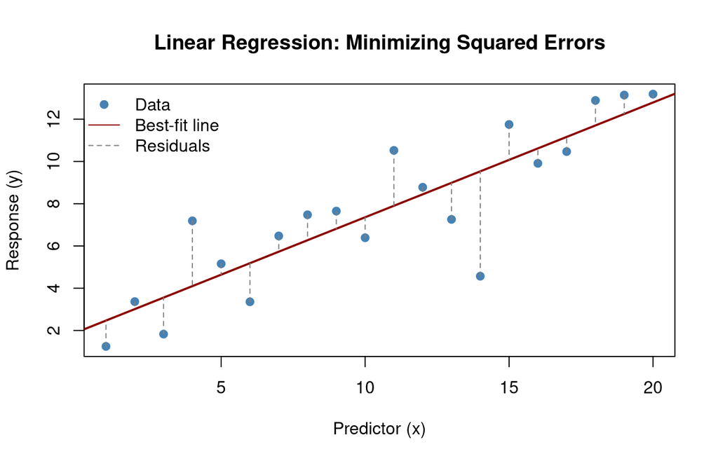

```r
# visual (ignore the code)
set.seed(1)
x <- 1:20
y <- 2 + 0.5*x + rnorm(20, 0, 2)
fit <- lm(y ~ x)

plot(x, y, pch = 19, col = "steelblue",
     main = "Linear Regression: Minimizing Squared Errors",
     xlab = "Predictor (x)", ylab = "Response (y)")
abline(fit, col = "darkred", lwd = 2)
segments(x, y, x, fitted(fit), col = "gray50", lty = 2)
legend("topleft", legend = c("Data", "Best-fit line", "Residuals"),
       col = c("steelblue", "darkred", "gray50"), pch = c(19, NA, NA),
       lty = c(NA, 1, 2), bty = "n")
```

### Fit the linear regression model using the `lm()` function

```r
############################################################
## (1) LINEAR REGRESSION - Baseline model
############################################################

fit_lm <- lm(bfi_mean ~ ., data = train)
summary(fit_lm)
```

```
##
## Call:
## lm(formula = bfi_mean ~ ., data = train)
##
## Residuals:
##      Min       1Q   Median       3Q      Max
## -0.42464 -0.06336  0.00714  0.07053  0.40838
##
## Coefficients:
##                                   Estimate Std. Error t value Pr(>|t|)
## (Intercept)                      5.436e-01  2.219e-01   2.450 0.014363 *
## mean_annual_precip_mm            1.550e-03  1.014e-03   1.530 0.126235
## precip_pct_change_annual         2.727e-02  1.154e-02   2.364 0.018148 *
## mean_annual_snow_cm             -1.003e-05  6.311e-05  -0.159 0.873721
## snow_pct_change_annual          -2.047e-03  3.492e-03  -0.586 0.557791
## mean_annual_temp_deg_c           9.089e-03  3.490e-03   2.605 0.009257 **
## temp_pct_change_annual           1.257e-05  3.021e-04   0.042 0.966809
## mean_annual_vpd_k_pa             3.431e-01  1.610e-01   2.132 0.033119 *
## vpd_pct_change_annual            1.424e-01  3.931e-02   3.624 0.000296 ***
## mean_annual_r_net_w_m2           1.669e-02  1.890e-02   0.883 0.377444
## r_net_pct_change_annual         -1.014e-02  5.841e-03  -1.736 0.082694 .
## magt_deg_c                      -2.230e-04  2.573e-03  -0.087 0.930934
## mean_annual_lai                  1.823e-03  2.554e-03   0.714 0.475577
## centroid_lat_dec_degree         -1.669e-03  2.265e-03  -0.737 0.461293
## elev_m                           1.236e-05  1.984e-05   0.623 0.533431
## reach_slope_m_m                  2.821e-01  4.322e-01   0.653 0.514058
## upstrm_drainage_area_km2         7.426e-08  5.789e-07   0.128 0.897943
## reach_length_km                 -1.967e-03  2.747e-04  -7.161 1.06e-12 ***
## stream_order.L                   1.922e-02  1.493e-01   0.129 0.897598
## stream_order.Q                   8.535e-02  1.255e-01   0.680 0.496456
## stream_order.C                   4.273e-02  8.203e-02   0.521 0.602444
## stream_order^4                   3.346e-02  4.591e-02   0.729 0.466190
## stream_order^5                  -1.491e-03  2.385e-02  -0.062 0.950175
## stream_order^6                  -7.716e-04  1.280e-02  -0.060 0.951932
## permafrost_typediscontinuous    -2.927e-02  9.283e-03  -3.153 0.001638 **
## permafrost_typesporadic         -2.756e-02  1.194e-02  -2.307 0.021142 *
## permafrost_typeisolated         -6.491e-02  1.402e-02  -4.631 3.83e-06 ***
## permafrost_typenone             -6.695e-02  1.700e-02  -3.938 8.45e-05 ***
## glacier_presenceglacier         -6.546e-02  6.923e-02  -0.946 0.344462
## alt_mean_m                      -1.248e-02  9.533e-03  -1.309 0.190735
## alt_pct_change_annual           -4.693e-03  2.059e-03  -2.279 0.022726 *
## permeability_log10m2             2.222e-03  1.261e-03   1.762 0.078134 .
## bulk_density_cg_cm_3             5.315e-04  2.957e-04   1.798 0.072370 .
## coarse_fragment_cm3_dm3          8.957e-05  6.405e-05   1.398 0.162161
## clay_content_g_kg               -3.165e-04  5.783e-05  -5.473 4.88e-08 ***
## soil_organic_carbon_100cm_kg_m2 -2.471e-04  1.698e-04  -1.456 0.145549
## aspect_sin                      -3.226e-04  3.250e-03  -0.099 0.920935
## aspect_cos                       3.872e-03  3.236e-03   1.196 0.231685
## ---
## Signif. codes:  0 '***' 0.001 '**' 0.01 '*' 0.05 '.' 0.1 ' ' 1
##
## Residual standard error: 0.1118 on 2430 degrees of freedom
## Multiple R-squared:  0.2185, Adjusted R-squared:  0.2066
## F-statistic: 18.36 on 37 and 2430 DF,  p-value: < 2.2e-16
```

### **Interpreting the Linear Regression Model**

0. **What’s going on with the `stream_order` variable?**

The `stream_order` variable represents the position of a stream within the river network — where **1st-order streams** are the smallest headwater channels and larger orders indicate progressively larger, downstream reaches. Because it encodes a natural hierarchy, `stream_order` is treated as an **ordered factor** in the model.

When an ordered factor is used in R, it is represented by a series of **orthogonal polynomial contrasts**, shown in the regression output as `.L`, `.Q`, `.C`, `^4`, and so on. These correspond to **linear**, **quadratic**, **cubic**, and higher-order trends across the ordered levels. This does *not* make the model nonlinear in the regression sense — the model is still linear in its coefficients — but it allows the effect of stream order on groundwater contribution to follow a **smooth or curved pattern** rather than being forced to increase or decrease strictly linearly.

In simple terms, these terms let the model detect whether `bfi_mean` changes steadily with stream size or whether it peaks or dips at intermediate stream orders. This is helpful because hydrologically, mid-order streams may behave differently from very small headwaters or large river channels, and the polynomial contrasts provide a flexible way to capture that pattern while keeping the model interpretable and statistically valid.

1. **Model fit and meaning** The overall ( R^2 = 0.22 ) indicates that about 22 % of the variation in groundwater contribution is explained by the predictors. Although this may appear modest, it is **quite strong for environmental and hydrologic data**, where natural variability is high. The model is statistically significant (( p < 2.2^{-16} )), showing that it captures meaningful, non-random structure.
2. **Key predictors and physical interpretation**
   - **Reach length** has a large negative coefficient (( p < 10^{-12} )), meaning that longer stream reaches are linked to *lower* baseflow index values.
   - **Clay content** is also strongly negative (( p < 10^{-7} )), suggesting that clay-rich soils restrict infiltration and reduce groundwater contribution.
   - **Mean annual temperature** and **vapor-pressure-deficit change** are positive and significant, implying that warming and drying trends enhance subsurface contributions.
3. `permafrost_type`
- In R, when you include a categorical variable (like `permafrost_type`) in a linear model, one category is automatically chosen as the **reference (baseline)**. The coefficients for the other categories represent how much higher or lower their predicted `bfi_mean` is **compared to that baseline**.
- If you didn’t explicitly change the reference, R will use the **first category in alphabetical order**. Given your variable levels (`continuous`, `discontinuous`, `sporadic`, `isolated`, `none`), the baseline is most likely **“continuous.”**
- Interpret the coefficients relative to the baseline

Here are the coefficients you have:

| Category | Coefficient | Interpretation (relative to *continuous*) |
| --- | --- | --- |
| discontinuous | −0.029 | Streams in discontinuous permafrost areas have, on average, a **0.03 lower** BFI than those in continuous permafrost. |
| sporadic | −0.028 | Streams in sporadic permafrost have a **0.03 lower** BFI than continuous permafrost areas. |
| isolated | −0.065 | Streams in isolated permafrost areas have a **0.07 lower** BFI than continuous permafrost. |
| none | −0.067 | Streams with no permafrost have a **0.07 lower** BFI than continuous permafrost. |

- What this means
  - Because all coefficients are **negative**, and the baseline (continuous permafrost) is **not shown but implicit**, this tells us that — in this dataset — **streams with less permafrost actually have lower groundwater contributions** than those in continuous permafrost regions.
  - That’s counterintuitive from a purely physical standpoint (since frozen ground usually limits infiltration), but statistically, it means that after controlling for temperature, soil, and drainage variables, the model finds **lower baseflow fractions in permafrost-free areas**.
4. **Unexpectedly weak predictors** Some variables that might seem hydrologically important—such as **precipitation**, **snow depth**, or **elevation**—are not significant once correlated climate and soil effects are accounted for. This highlights how regression isolates each variable’s *unique* influence after adjusting for others.
5. **Model behavior and insight** The residual standard error ((~0.11)) indicates predictions are typically within about 0.1 units of observed values on a 0–1 scale. The results reinforce physically consistent relationships: **permafrost continuity**, **soil texture**, and **channel geometry** emerge as dominant controls on groundwater contributions, while climate trends modulate these effects. This demonstrates how even a relatively simple linear model can uncover meaningful, process-based patterns across a complex landscape.

   > The significant F-statistic (p < 2.2e−16) confirms the model, as a whole, fits substantially better than a null (mean-only) model — so you’ve captured meaningful signal, not random noise.

### Predictions on test data

```r
# Predictions on test data
pred_lm <- predict(fit_lm, newdata = test)
```

### Compute RMSE and $R^2$ using Test data (Evaluation)

```r
# Evaluation
rmse_lm <- sqrt(mean((test$bfi_mean - pred_lm)^2))
rsq_lm  <- cor(test$bfi_mean, pred_lm)^2

cat("\nLinear Regression RMSE:", round(rmse_lm,3),
    " | R-squared:", round(rsq_lm,3), "\n")
```

```
##
## Linear Regression RMSE: 0.116  | R-squared: 0.152
```

The linear regression model achieved an **RMSE of 0.12** and an **R² of 0.152**, meaning that, on average, the model’s predictions differ from the observed `bfi_mean` values by about **0.12 units** on a 0–1 scale, while explaining roughly **15% of the variation** in groundwater contribution across sites. Although this indicates a moderate level of predictive accuracy, it still captures meaningful large-scale patterns in the data — a solid baseline performance for comparison with more advanced models like LASSO, Elastic Net, and AHRLR that we will explore next.

## Shrinkage & Variable Selection Models

As datasets grow larger and more complex, traditional linear regression often struggles to balance accuracy and interpretability. When we have many predictors—especially if some are highly correlated or only weakly related to the outcome—the model can become unstable and overfit the training data. Overfitting means the model captures random noise rather than the true underlying relationships, which reduces its predictive power on new data.

To address these challenges, we use shrinkage and variable selection methods, such as Ridge Regression, LASSO (Least Absolute Shrinkage and Selection Operator), and Elastic Net. These techniques introduce a penalty on the size of the regression coefficients, effectively “shrinking” less important ones toward zero.

Shrinkage helps control model complexity and improves prediction accuracy.

Variable selection (as in LASSO) automatically identifies the most relevant predictors by setting some coefficients exactly to zero, simplifying the model.

In short, shrinkage and selection methods provide a principled way to build models that are more stable, interpretable, and generalizable, especially when dealing with high-dimensional or correlated data.

## (2) LASSO REGRESSION

### **Concept**

LASSO (Least Absolute Shrinkage and Selection Operator) is an extension of linear regression that improves model performance when there are **many correlated or less useful predictors**. It adds a **penalty** that forces some coefficients to shrink toward zero, which helps simplify the model and prevent overfitting.

### **Model Equation**

$${y}_i = \beta_0 + \beta_1 x_{i1} +
\beta_2 x_{i2} + \cdots + \beta_p x_{ip}+\epsilon_i$$

This part is identical to ordinary linear regression — but how we estimate the slopes (($\beta$)) changes.

### **Optimization Objective**

LASSO finds the coefficients that minimize both the squared prediction error **and** the total absolute size of the coefficients:

$$\min_{\beta_0, \beta_1, \dots, \beta_p}
\sum_{i=1}^{n} \left( y_i - \beta_0 - \sum_{j=1}^{p} \beta_j x_{ij}
\right)^2 + \lambda \sum_{j=1}^{p} |\beta_j|$$

The tuning parameter ( $\lambda$ ) controls how strong the penalty is:

- A small ( $\lambda$ ) → coefficients stay close to the linear regression values.
- A large ( $\lambda$ ) → coefficients are pulled toward zero, and some become exactly zero.

### **Visual Aid: Shrinking Coefficients**

In a plot of **λ (penalty)** on the x-axis and **coefficient values** on the y-axis, you’ll see each coefficient’s line **shrink toward zero** as λ increases. Once λ is large enough, only a few predictors remain nonzero — the “selected” variables.

### **Key Idea (in plain English)**

> LASSO works like linear regression with a self-control mechanism: it still fits a line through the data, but it automatically **shrinks or removes** predictors that contribute little to the model. The result is a **simpler, more stable, and interpretable** model.

### Create model matrix (glmnet requires matrix inputs)

```r
# Create model matrix (glmnet requires matrix inputs)
x_train <- model.matrix(bfi_mean ~ ., data = train)[, -1]
y_train <- train$bfi_mean
x_test  <- model.matrix(bfi_mean ~ ., data = test)[, -1]
y_test  <- test$bfi_mean
```

### Cross-validated LASSO to pick best lambda

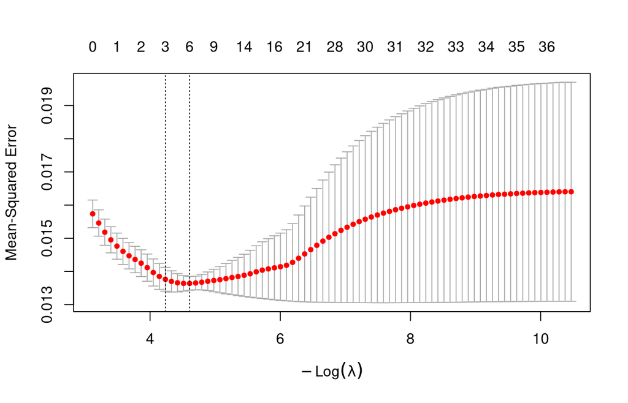

```r
# Cross-validated LASSO to pick best lambda
cv_lasso <- cv.glmnet(x_train, y_train, alpha = 1, nfolds = 5)
plot(cv_lasso)    # shows RMSE vs log(lambda)
```

```r
best_lambda <- cv_lasso$lambda.min
best_lambda
```

```
## [1] 0.00997893
```

The plot from `cv_lasso` shows the **cross-validated error** (typically RMSE or deviance) for a range of penalty values (( $\lambda$ )) used in the LASSO model. The curve usually dips to a minimum and then rises again as the penalty becomes too strong.

### Fit final model at `best_lambda`

```r
# Fit final model at optimal lambda
fit_lasso <- glmnet(x_train, y_train, alpha = 1, lambda = best_lambda)
coef(fit_lasso)
```

```
## 39 x 1 sparse Matrix of class "dgCMatrix"
##                                            s0
## (Intercept)                      6.001176e-01
## mean_annual_precip_mm            .
## precip_pct_change_annual         .
## mean_annual_snow_cm              .
## snow_pct_change_annual           .
## mean_annual_temp_deg_c           7.252624e-03
## temp_pct_change_annual           .
## mean_annual_vpd_k_pa             5.347300e-02
## vpd_pct_change_annual            .
## mean_annual_r_net_w_m2           .
## r_net_pct_change_annual          .
## magt_deg_c                       .
## mean_annual_lai                  .
## centroid_lat_dec_degree          .
## elev_m                           .
## reach_slope_m_m                  .
## upstrm_drainage_area_km2         .
## reach_length_km                 -9.407050e-04
## stream_order.L                   .
## stream_order.Q                   3.141864e-02
## stream_order.C                   .
## stream_order^4                   .
## stream_order^5                   .
## stream_order^6                   .
## stream_order^7                   .
## permafrost_typediscontinuous     .
## permafrost_typesporadic          .
## permafrost_typeisolated          .
## permafrost_typenone              .
## glacier_presenceglacier          .
## alt_mean_m                       .
## alt_pct_change_annual            .
## permeability_log10m2             2.494306e-04
## bulk_density_cg_cm_3             .
## coarse_fragment_cm3_dm3          .
## clay_content_g_kg               -8.999784e-05
## soil_organic_carbon_100cm_kg_m2  .
## aspect_sin                       .
## aspect_cos                       .
```

### **Interpreting the LASSO Model**

1. **LASSO dramatically simplified the model** Out of nearly 40 predictors, the LASSO retained only **six variables**:
   - `mean_annual_temp_deg_c`
   - `mean_annual_vpd_k_pa`
   - `reach_length_km`
   - `stream_order.Q`
   - `permeability_log10m2`
   - `clay_content_g_kg` All other coefficients were shrunk exactly to zero. This illustrates LASSO’s strength — it performs **automatic variable selection**, removing predictors that add little to the model’s predictive power and leaving a concise, interpretable subset.
2. **The retained variables make strong physical sense**
   - **Temperature** and **VPD** describe climatic influence on evapotranspiration and recharge.
   - **Reach length** and **stream order (quadratic)** describe channel network geometry — the “plumbing” of the landscape.
   - **Permeability** and **clay content** capture subsurface flow capacity and infiltration limitations.

     LASSO thus bridges the major hydrologic dimensions — **climate, landscape, and subsurface properties** — all without manual variable selection.
3. **The signs of the coefficients align with hydrologic theory**
   - **Clay content (−)** → higher clay = lower infiltration and reduced groundwater contribution.
   - **Reach length (−)** → longer channels show less groundwater influence.
   - **Temperature and VPD (+)** → warmer and drier regions exhibit higher groundwater fraction, possibly due to thawing or altered recharge pathways.
4. **WOW takeaway** The LASSO reduced the model from **39 predictors to just six** while preserving physically meaningful relationships. It automatically identified the dominant drivers — the same ones an expert might choose — through a purely **data-driven learning process**. This demonstrates how regularization can reveal **the essential structure in complex environmental data** while improving model stability and interpretability.

### Predict using test data and evaluate

```r
# Predict and evaluate
pred_lasso <- predict(fit_lasso, newx = x_test)
```

### Compute RMSE and $R^2$ using Test data (Evaluation)

```r
rmse_lasso <- sqrt(mean((y_test - pred_lasso)^2))
rsq_lasso  <- cor(y_test, pred_lasso)^2

cat("\nLASSO RMSE:", round(rmse_lasso,3),
    " | R-squared:", round(rsq_lasso,3), "\n")
```

```
##
## LASSO RMSE: 0.117  | R-squared: 0.14
```

The **LASSO model** achieved an **RMSE of 0.117** and an **R² of 0.14**, which is very close to the linear regression model’s performance but with only a fraction of the predictors. This shows that LASSO delivers nearly the **same predictive accuracy** while producing a **much simpler and more interpretable model**. In practice, this balance between simplicity and accuracy is exactly what makes regularization methods like LASSO so valuable — they generalize better, reduce overfitting, and highlight the most important variables driving groundwater contributions.

## (3) ELASTIC NET REGRESSION

### **The idea**

Elastic Net combines the strengths of **Ridge** and **LASSO** regression. Like LASSO, it can shrink some coefficients to zero (performing variable selection), and like Ridge, it handles **correlated predictors** more smoothly by sharing their effects instead of forcing one to drop out.

This makes Elastic Net a great middle ground between the two methods — it balances model simplicity and stability.

### **Model Equation**

$${y}_i = \beta_0 + \beta_1 x_{i1} +
\beta_2 x_{i2} + \cdots + \beta_p x_{ip}+\epsilon_i$$

### **Optimization Objective**

$$\min_{\beta_0, \beta_1, \dots, \beta_p}
\sum_{i=1}^{n} \left( y_i - \beta_0 - \sum_{j=1}^{p} \beta_j x_{ij}
\right)^2 + \lambda \left[
(1 - \alpha) \sum_{j=1}^{p} \beta_j^2 + \alpha \sum_{j=1}^{p}
|\beta_j|\right]$$

Here:

- $\lambda$ controls the overall penalty strength (like before).
- $\alpha$ controls the **mix** between Ridge ($L_2$) and LASSO ($L_1$):
- $\alpha = 0$ → Ridge Regression
- $\alpha = 1$ → LASSO Regression
- $0 < \alpha < 1$ → Elastic Net (a blend of both)

### **Key idea**

> Elastic Net is a **hybrid shrinkage method** that combines the variable selection of LASSO with the stability of Ridge. It’s especially effective when predictors are **highly correlated** or when there are **many more predictors than observations (p > n)**.

### Create model matrix (glmnet requires matrix inputs)

```r
# Already done
```

### Cross-validated Enet to pick best lambda

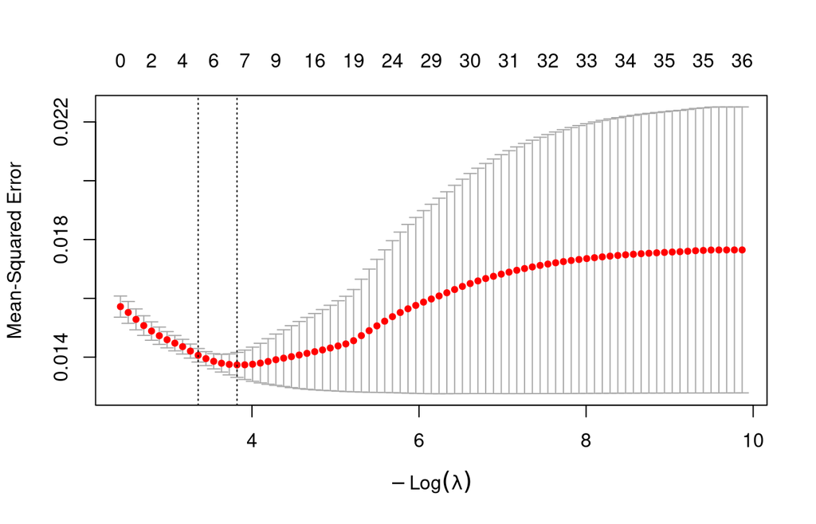

```r
# Cross-validated ENET to pick best lambda
cv_enet <- cv.glmnet(x_train, y_train, alpha = 0.5, nfolds = 5)
plot(cv_enet)    # shows RMSE vs log(lambda)
```

```r
best_lambda_enet <- cv_enet$lambda.min
best_lambda_enet
```

```
## [1] 0.02190373
```

### Fit final model at `best_lambda_enet`

```r
# Fit final model at optimal lambda
fit_enet <- glmnet(x_train, y_train, alpha = 0.5, lambda = best_lambda_enet)
coef(fit_enet)
```

```
## 39 x 1 sparse Matrix of class "dgCMatrix"
##                                            s0
## (Intercept)                      5.473688e-01
## mean_annual_precip_mm            .
## precip_pct_change_annual         .
## mean_annual_snow_cm              .
## snow_pct_change_annual           .
## mean_annual_temp_deg_c           4.687992e-03
## temp_pct_change_annual           .
## mean_annual_vpd_k_pa             1.386127e-01
## vpd_pct_change_annual            .
## mean_annual_r_net_w_m2           .
## r_net_pct_change_annual          .
## magt_deg_c                       9.541105e-05
## mean_annual_lai                  .
## centroid_lat_dec_degree          .
## elev_m                           .
## reach_slope_m_m                  .
## upstrm_drainage_area_km2         .
## reach_length_km                 -7.722631e-04
## stream_order.L                   .
## stream_order.Q                   2.479099e-02
## stream_order.C                  -2.757078e-03
## stream_order^4                   .
## stream_order^5                   .
## stream_order^6                   .
## stream_order^7                   .
## permafrost_typediscontinuous     .
## permafrost_typesporadic          .
## permafrost_typeisolated          .
## permafrost_typenone              .
## glacier_presenceglacier          .
## alt_mean_m                       .
## alt_pct_change_annual            .
## permeability_log10m2             5.976816e-04
## bulk_density_cg_cm_3             .
## coarse_fragment_cm3_dm3          .
## clay_content_g_kg               -7.396067e-05
## soil_organic_carbon_100cm_kg_m2  .
## aspect_sin                       .
## aspect_cos                       .
```

### Predict using test data and evaluate

```r
# Predict and evaluate
pred_enet <- predict(fit_enet, newx = x_test)
```

### Compute RMSE and $R^2$ using Test data (Evaluation)

```r
rmse_enet <- sqrt(mean((y_test - pred_enet)^2))
rsq_enet <- cor(y_test, pred_enet)^2

cat("\nENET RMSE:", round(rmse_enet,3),
    " | R-squared:", round(rsq_enet,3), "\n")
```

```
##
## ENET RMSE: 0.117  | R-squared: 0.14
```

The Elastic Net model achieved predictive accuracy comparable to the LASSO model (RMSE ≈ 0.117, R² ≈ 0.14), while maintaining a more stable solution in the presence of correlated predictors. This highlights Elastic Net’s advantage — it balances model simplicity and robustness, capturing key relationships without overfitting or losing important correlated variables.

### **The idea**

AHRLR builds on the strengths of **LASSO**, **Adaptive LASSO**, and **Relaxed LASSO** to achieve better variable selection and lower bias. It is a **two-stage procedure** designed to:

1. Select important predictors (like LASSO), and
2. Refit them with adaptive weights and reduced shrinkage (relaxation), improving estimation accuracy and model stability.

This makes AHRLR both **sparse** (many coefficients are zero) and **less biased** for the variables that remain.

### **Model Equation**

$${y}_i = \beta_0 + \beta_1 x_{i1} +
\beta_2 x_{i2} + \cdots + \beta_p x_{ip}+\epsilon_i$$

### **Optimization Objective**

AHRLR solves the following adaptive and relaxed penalized least squares problem:

$$\min_{\beta_0, \beta_1, \dots, \beta_p}
\sum_{i=1}^{n}
\left( y_i - \beta_0 - \sum_{j=1}^{p} \beta_j x_{ij} \right)^2+
\lambda_1 \sum_{j=1}^{p} w_j |\beta_j|+ \lambda_2 (1 - \phi)
\sum_{j=1}^{p} \beta_j^2$$

where:

- $w_j = 1 / |\hat{\beta}_j^{(init)}|^{\gamma}$ are **adaptive weights** based on an initial estimate (e.g., OLS or LASSO).
- $\lambda_1$ controls sparsity (LASSO-type penalty).
- $\lambda_2$ and $\phi$ control the relaxation and bias adjustment.

This two-stage process allows flexible control over selection and shrinkage strength.

### **Visual Aid: Two-stage learning**

You can visualize AHRLR as a **two-step process**:

1. **Stage 1:** Apply LASSO to identify important predictors.
2. **Stage 2:** Refit those predictors with adaptive weights and relaxed penalties, giving them room to “breathe” — stronger effects shrink less, weaker ones may vanish.

This results in a model that is **both parsimonious and accurate**.

### **Key idea**

> AHRLR combines adaptive weighting and relaxation to reduce LASSO’s bias while keeping its ability to select variables. It bridges the gap between model simplicity and unbiased estimation, making it particularly effective for data with **correlated predictors** or **mixed signal strengths**.

```r
# Quick Start ----------------------------

# 1. Load AHRLR functions
source("https://hasthika.github.io/Rpacks/ahrlr_fit.txt")

# 2. Fit model
fit <- fit_AHRLR(x_train, y_train, lambda2 = 1)

# 3. Inspect selected variables
fit$selected_vars
```

```
## [1] "precip_pct_change_annual" "mean_annual_temp_deg_c"
## [3] "mean_annual_vpd_k_pa"     "vpd_pct_change_annual"
## [5] "reach_length_km"          "stream_order.Q"
## [7] "stream_order^5"           "permafrost_typeisolated"
## [9] "clay_content_g_kg"
```

```r
# 4. Predict on new data
pred_ahrlr <- predict_AHRLR(fit, newx = x_test)

# 5. Optional summary
summarize_AHRLR(fit, X_test = x_test, y_test = y_test)
```

```
## AHRLR model summary
## -------------------
## lambda.min: 0.1316359
## Selected variables (9):
##   precip_pct_change_annual, mean_annual_temp_deg_c, mean_annual_vpd_k_pa, vpd_pct_change_annual, reach_length_km, stream_order.Q, stream_order^5, permafrost_typeisolated, clay_content_g_kg
## Test RMSE: 0.1163
```

### **Interpreting the AHRLR Model**

1. **AHRLR identified a comprehensive yet stable set of predictors**  
   The Adaptive Hybrid Relaxed Lasso Regression (AHRLR) retained **nine meaningful variables**, expanding slightly beyond LASSO and ENet:
   - `precip_pct_change_annual`
   - `mean_annual_temp_deg_c`
   - `mean_annual_vpd_k_pa`
   - `vpd_pct_change_annual`
   - `reach_length_km`
   - `stream_order.Q`
   - `stream_order^5`
   - `permafrost_typeisolated`
   - `clay_content_g_kg`

   Compared with LASSO and ENet, AHRLR recovers a slightly broader, more balanced set of predictors — capturing both **climatic** and **physical watershed** controls while avoiding over-shrinkage.
2. **Why this is powerful**  
   AHRLR’s two-stage design first performs variable selection (like LASSO) and then *relaxes* the shrinkage with adaptive weights.  
   This means strong signals are shrunk less, and weaker but still relevant predictors can re-enter the model.  
   As a result, AHRLR often **recovers variables that LASSO or ENet penalized too heavily**, providing a richer yet still stable model.
3. **Hydrologic interpretation**
- **Climate effects:**  
  Changes in precipitation, temperature, and vapor pressure deficit (VPD) highlight the influence of **long-term climate trends** on groundwater contribution.
- **Landscape effects:**  
  Variables like `reach_length_km` and `stream_order` describe **basin size and connectivity**, controlling how surface and subsurface flows interact.
- **Subsurface effects:**  
  `permafrost_typeisolated` and `clay_content_g_kg` reflect **groundwater movement capacity** — regions with more clay or isolated permafrost show **reduced groundwater inputs**.

Together, these findings suggest that **climate, topography, and soil composition** jointly determine how much groundwater sustains streamflow.

4. **WOW takeaway**  
   AHRLR bridges the gap between the overly sparse LASSO/ENet models and the fully complex regression.  
   It preserves interpretability while improving bias and stability — yielding a **physically coherent, multi-process model** that connects climate variability, landscape structure, and soil permeability.  
   This balance of parsimony and completeness is what makes AHRLR especially powerful for environmental modeling.

```r
rmse_AHRLR <- sqrt(mean((y_test - pred_ahrlr)^2))
rsq_AHRLR <- cor(y_test, pred_ahrlr)^2

cat("\nAHRLR RMSE:", round(rmse_AHRLR, 3),
    " | R-squared:", round(rsq_AHRLR, 3), "\n")
```

```
##
## AHRLR RMSE: 0.116  | R-squared: 0.147
```

The **AHRLR model** achieved an **RMSE of 0.116** and an **R² of 0.147**, performing about the same as the linear regression and LASSO models in terms of predictive accuracy. What makes AHRLR stand out is that it keeps slightly **more meaningful variables** while still maintaining a low error rate. This means it captures a **broader picture of the system** — combining climate, landscape, and soil effects — without losing predictive strength.

# Transition to Tree-Based Models

While linear, Ridge, LASSO, and Elastic Net regressions are powerful and interpretable, they all assume a linear relationship between predictors and the response. In many real-world situations, that assumption can be too limiting — relationships may be nonlinear, involve interactions among variables, or change across different ranges of the predictors.

To capture these complex patterns, we turn to tree-based models, which divide the data into smaller, more homogeneous groups based on predictor values. Each split represents a simple decision rule, and together these rules form a tree-like structure that is easy to interpret.

There are two main types of tree-based models:

- Regression Trees, used when the outcome variable is continuous (e.g., predicting groundwater contribution).
- Classification Trees, used when the outcome variable is categorical (e.g., predicting whether a stream is glacier-fed or not).

In this workshop, we will focus on regression trees to stay within the continuous-response setting, then extend the idea to more advanced ensemble methods like Bagging, Random Forest, and Boosting to improve predictive performance and stability.

## (5) DECISION TREE (A Regression Tree In This Case) - Interpretable nonlinear model

```r
fit_tree <- rpart(bfi_mean ~ ., data = train,
                  control = rpart.control(cp = 0.01, maxdepth = 6))
```

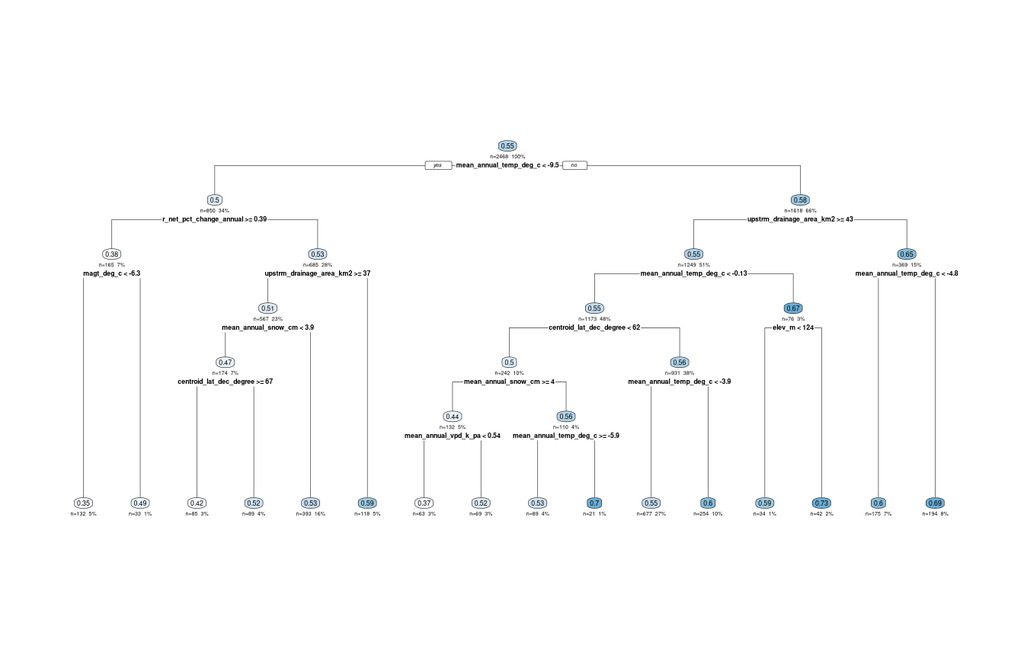

```r
rpart.plot(fit_tree, type = 2, extra = 101, under = TRUE, faclen = 0)
```

### **Interpreting the Regression Tree**

This regression tree predicts the **mean groundwater contribution (`bfi_mean`)** using climate, location, and watershed variables.  
Each split represents a **decision rule** that divides the data into groups with more similar groundwater contributions.  
The predicted value at each terminal node (`yval`) is the **average `bfi_mean`** for sites that meet all conditions along that branch.

#### 1. **Top split — Mean annual temperature**

The first and most important division occurs at  
`mean_annual_temp_deg_c < -9.545`, separating **very cold (Arctic)** regions from **warmer (sub-Arctic to temperate)** ones.  
This confirms that **temperature is the dominant control** on groundwater contribution across the study area.

- **Cold regions (≤ −9.5 °C):** average groundwater contribution ≈ 0.50
- **Warmer regions (> −9.5 °C):** average groundwater contribution ≈ 0.58

Warmer basins tend to have **greater groundwater influence**, consistent with permafrost thaw and deeper infiltration.

#### 2. **Cold branch (≤ −9.5 °C)**

Within the cold group, variation depends on **net radiation trend** and **drainage area**.

- **High net radiation trend (r_net_pct_change_annual ≥ 0.385)** and **very low ground temperatures (magt_deg_c < −6.3)**  
  → extremely low groundwater contributions (≈ 0.35–0.38).  
  These are the coldest, most frozen landscapes with minimal subsurface flow.
- **Cold areas with weaker radiation increase and larger drainage areas (≥ 37 km²)**  
  → moderately higher groundwater values (≈ 0.52).
- **Small, cold basins (< 37 km²)**  
  → the highest BFI in the cold branch (≈ 0.59), suggesting that **small, well-connected headwaters** can still maintain notable groundwater input when not fully frozen.

#### 4. **Overall pattern**

The tree highlights a **hierarchical climate–basin size control**:

| Dominant Condition | Typical BFI | Interpretation |
| --- | --- | --- |
| Very cold (≤ −9.5 °C), frozen soils | 0.35–0.45 | Minimal groundwater contribution |
| Cold, larger basins | 0.50–0.53 | Slightly increased baseflow buffering |
| Moderate temperature, large basins | 0.55–0.60 | Sustained groundwater flow |
| Warm, small basins | 0.65–0.70 | Strongest groundwater–surface exchange |

```r
# Predict and evaluate
pred_tree <- predict(fit_tree, newdata = test)
rmse_tree <- sqrt(mean((test$bfi_mean - pred_tree)^2))
rsq_tree  <- cor(test$bfi_mean, pred_tree)^2

cat("\nDecision Tree RMSE:", round(rmse_tree,3),
    " | R-squared:", round(rsq_tree,3), "\n")
```

```
##
## Decision Tree RMSE: 0.104  | R-squared: 0.32
```

## Why Go Beyond a Single Tree?

Decision trees are powerful because they are easy to interpret and can capture nonlinear relationships automatically. However, a single tree can be unstable — small changes in the data can lead to a very different tree structure — and its predictions may not be as accurate as more robust methods. This happens because trees have high variance: they tend to fit the training data closely but may not generalize well to new observations.

To overcome these limitations, we use ensemble methods, which combine the predictions of many trees to create a more stable and accurate model.

- **Bagging** (Bootstrap Aggregating) reduces variance by building many trees on random bootstrap samples of the data and averaging their predictions.
- **Random Forest** extends bagging by adding another layer of randomness — at each tree split, only a random subset of predictors is considered — which further decorrelates the trees and improves performance.
- **Boosting** takes a different approach by building trees sequentially, where each new tree focuses on correcting the errors made by the previous ones.

Together, these ensemble techniques make tree-based models more accurate, stable, and resistant to overfitting, while still retaining the ability to model complex, nonlinear relationships.

## (6) BAGGING - Averaging many bootstrap trees

**Bagging** (Bootstrap Aggregating) is a simple but powerful way to improve the stability and accuracy of decision trees. The idea is to create *many* *bootstrap* *samples* — random samples of the training data taken with replacement — and fit a separate tree to each one. Each tree may look a little different because it sees a slightly different subset of the data.

When making predictions, we average the results from all these trees (or take a majority vote for classification). Averaging helps cancel out random fluctuations and reduces the variance of the model, leading to more reliable predictions.

However, the main **disadvantage** of bagging is that it sacrifices interpretability — since predictions come from the average of many trees, it’s no longer clear how individual predictors influence the outcome. In other words, bagging gives up some transparency in exchange for greater accuracy and stability.

In short:

> Bagging = Build many trees on random samples + average their predictions. It smooths out noisy individual trees to produce a more stable and accurate ensemble model, though at the cost of losing a simple, single-tree interpretation.

```r
############################################################
## (6) BAGGING - Averaging many bootstrap trees
############################################################

fit_bag <- bagging(bfi_mean ~ ., data = train, nbagg = 50)  # 50 bootstraps
pred_bag <- predict(fit_bag, newdata = test)

rmse_bag <- sqrt(mean((test$bfi_mean - pred_bag)^2))
rsq_bag  <- cor(test$bfi_mean, pred_bag)^2

cat("\nBagging RMSE:", round(rmse_bag,3),
    " | R-squared:", round(rsq_bag,3), "\n")
```

```
##
## Bagging RMSE: 0.097  | R-squared: 0.405
```

### **Interpreting the Bagging Model**

This means Bagging explains nearly **40% of the variation** in groundwater contribution — about **2.5 times more** than the linear model — and predicts much more accurately (lower RMSE).

The improvement happens because Bagging combines results from **many decision trees** built on **different bootstrap samples** of the data. By averaging across many trees, the model:

- **Reduces variance** (each tree may overfit slightly, but their average is stable),
- **Captures nonlinear relationships** that linear models miss.

> “Bagging outperforms linear methods because it can capture complex, nonlinear patterns in how climate, soils, and landscape interact — not just straight-line effects. But it sacrifices interpretability.

## (7) RANDOM FOREST - Bagging + random feature selection

Random Forest builds on the idea of bagging but adds another clever layer of randomness to further improve performance. Like bagging, it creates many bootstrap samples and grows a separate decision tree for each. However, when a tree is being built, the algorithm does not consider all predictors at each split — instead, it selects a random subset of features and chooses the best split only among them.

This extra randomness helps make each tree more unique and less correlated with the others. When the predictions from all trees are averaged (for regression) or voted on (for classification), the result is a model that is typically more accurate and more robust than either a single tree or even plain bagging.

The trade-off is similar to bagging: interpretability is reduced because we now have hundreds of trees instead of one, but we gain excellent predictive power and strong resistance to overfitting.

In short:

> Random Forest = Bagging + Random Feature Selection at Each Split This approach decorrelates trees, reduces variance, and usually delivers one of the best out-of-the-box predictive models.

```r
############################################################
## (7) RANDOM FOREST - Bagging + random feature selection
############################################################

fit_rf <- randomForest(bfi_mean ~ ., data = train,
                       ntree = 300, mtry = floor(sqrt(ncol(train)-1)),
                       importance = TRUE)

print(fit_rf)
```

```
##
## Call:
##  randomForest(formula = bfi_mean ~ ., data = train, ntree = 300,      mtry = floor(sqrt(ncol(train) - 1)), importance = TRUE)
##                Type of random forest: regression
##                      Number of trees: 300
## No. of variables tried at each split: 5
##
##           Mean of squared residuals: 0.007708973
##                     % Var explained: 51.05
```

[figure not shown]

```r
varImpPlot(fit_rf, main = "Variable Importance (Random Forest)")
```

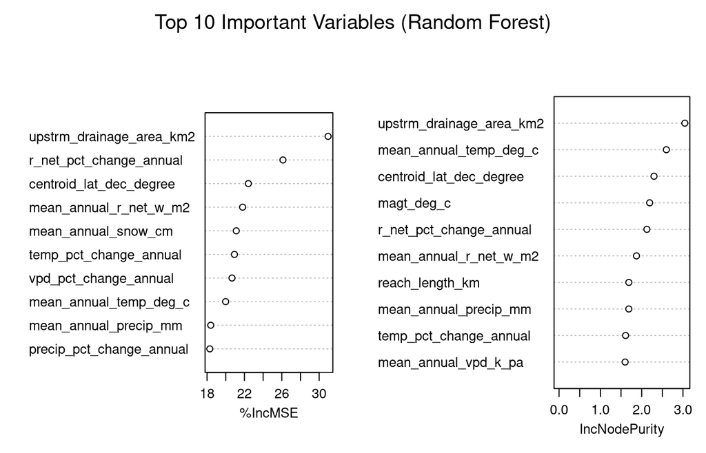

```r
# Simplify the Random Forest importance plot
varImpPlot(fit_rf,
           n.var = 10,                # show only top 10 variables
           main = "Top 10 Important Variables (Random Forest)",
           cex = 0.8)                 # shrink label text for readability
```

```r
pred_rf <- predict(fit_rf, newdata = test)
rmse_rf <- sqrt(mean((test$bfi_mean - pred_rf)^2))
rsq_rf  <- cor(test$bfi_mean, pred_rf)^2

cat("\nRandom Forest RMSE:", round(rmse_rf,3),
    " | R-squared:", round(rsq_rf,3), "\n")
```

```
##
## Random Forest RMSE: 0.089  | R-squared: 0.512
```

### **Interpreting Variable Importance (Random Forest)**

This plot shows the **top 10 most important predictors** of groundwater contribution (`bfi_mean`) identified by the Random Forest model. Each variable’s importance is measured in two ways:

- **%IncMSE (left):** how much the model’s prediction error increases when that variable’s values are randomly shuffled. → A bigger value means the variable is more important for accurate predictions.
- **IncNodePurity (right):** how much each variable helps reduce variation (impurity) when the trees split on it.

From both measures, we can see that:

- **Upstream drainage area** and Temperature and energy variables — including `mean_annual_temp_deg_c`, `r_net_pct_change_annual`, and `mean_annual_r_net_w_m2` highlight the strong role of climate and surface energy balance in shaping groundwater contributions.

## (8) GRADIENT BOOSTING - Sequential tree learning

Gradient Boosting is an advanced ensemble method that builds trees sequentially, where each new tree learns from the mistakes of the previous ones. Unlike bagging or random forests, which grow many independent trees and average their results, boosting takes an iterative approach: it starts with a simple model and gradually improves it by focusing on the observations that were hardest to predict.

At each step, a new tree is fit to the residual errors (the difference between the actual and predicted values), and its predictions are combined with the previous model to reduce overall error. This process continues for many rounds, producing a strong predictive model from many weak learners.

The key idea is that each tree “boosts” the performance of the ensemble by correcting earlier errors. The method is highly flexible and powerful, often achieving excellent accuracy. However, it comes with trade-offs — gradient boosting can be computationally intensive and prone to overfitting if too many trees are grown or the learning rate is too high.

In short:

> Gradient Boosting = Sequential tree learning where each tree corrects the errors of the previous ones.

```r
############################################################
## (8) GRADIENT BOOSTING - Sequential tree learning
############################################################

# Prepare data matrices for xgboost
x_train <- model.matrix(bfi_mean ~ ., data = train)[, -1]
x_test  <- model.matrix(bfi_mean ~ ., data = test)[, -1]
y_train <- train$bfi_mean
y_test  <- test$bfi_mean

# xgboost requires numeric matrices only
dtrain <- xgb.DMatrix(data = x_train, label = y_train)
dtest  <- xgb.DMatrix(data = x_test,  label = y_test)

# Train model (tweak parameters as needed)
fit_xgb <- xgboost(
  data = dtrain,
  objective = "reg:squarederror",
  nrounds = 300,       # number of boosting iterations
  eta = 0.05,          # learning rate
  max_depth = 5,       # depth of trees
  subsample = 0.8,     # fraction of data for each tree
  colsample_bytree = 0.8,
  verbose = 0
)

# Predict and evaluate
pred_xgb <- predict(fit_xgb, newdata = dtest)
rmse_xgb <- sqrt(mean((y_test - pred_xgb)^2))
rsq_xgb  <- cor(y_test, pred_xgb)^2

cat("\nBoosting (XGBoost) RMSE:", round(rmse_xgb,3),
    " | R-squared:", round(rsq_xgb,3), "\n")
```

```
##
## Boosting (XGBoost) RMSE: 0.091  | R-squared: 0.478
```

## COMPARISON SUMMARY

```r
############################################################
## COMPARISON SUMMARY
############################################################

results <- data.frame(
  Model = c("Linear", "LASSO", "Enet", "AHRLR", "Tree", "Bagging", "RF", "Boosting"),
  RMSE  = c(rmse_lm, rmse_lasso, rmse_enet, rmse_AHRLR, rmse_tree, rmse_bag, rmse_rf, rmse_xgb),
  R2    = c(rsq_lm, rsq_lasso, rsq_enet, rsq_AHRLR, rsq_tree, rsq_bag, rsq_rf, rsq_xgb)
)

print(results[order(results$RMSE), ], row.names = FALSE)
```

```
##     Model       RMSE        R2
##        RF 0.08868245 0.5121020
##  Boosting 0.09061455 0.4778010
##   Bagging 0.09741966 0.4047560
##      Tree 0.10396971 0.3199305
##    Linear 0.11615648 0.1524623
##     AHRLR 0.11633932 0.1472868
##     LASSO 0.11656061 0.1397317
##      Enet 0.11681202 0.1402390
```

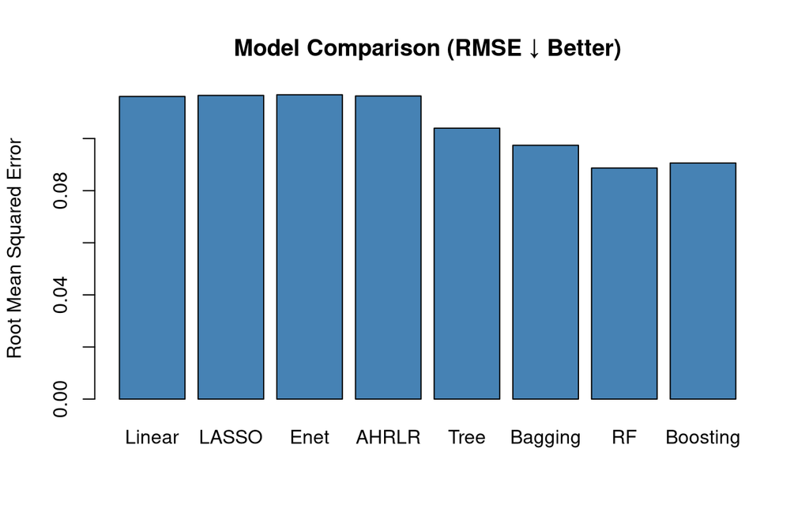

```r
# Optional: bar plot of model RMSEs
barplot(results$RMSE, names.arg = results$Model,
        col = "steelblue", main = "Model Comparison (RMSE ↓ Better)",
        ylab = "Root Mean Squared Error")
```

## **Final Summary**

We compared several supervised learning models for predicting **mean groundwater contribution (`bfi_mean`)**. The table below summarizes their predictive accuracy using **Root Mean Squared Error (RMSE)** and **R-squared (R²)** on the test data.

[output not shown]

### **In summary**

> The results highlight a clear trade-off in supervised learning: **Linear and shrinkage models** are simpler and interpretable, **Tree-based ensembles** are more powerful and flexible.

Together, they demonstrate how modern machine-learning tools can uncover complex, nonlinear relationships between climate, landscape, and groundwater systems — giving us both scientific insight and stronger predictive capability.